# PROGETTO ESAME APPRENDIMENTO STATISTICO

# Loading Plot

Il loading plot mostra la relazione tra le Principal Component e le variabili originali. Si utilizza per mostrare come le features originali si relazionano ai PC, o viceversa.

##### Si mostrino di seguito i loading plot relativi alle componenti principali della PCA in 2 dimensioni e 3 dimensioni

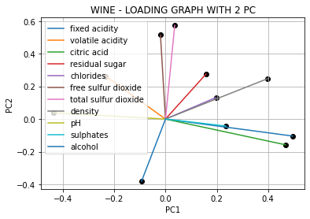

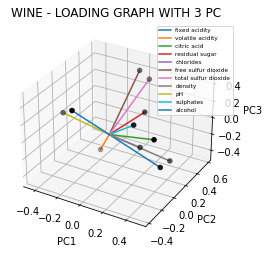

```python
plt.figure()
for i in range(pca_wine_m.n_features_):
    plt.plot([0, pca_wine_m.components_[0, i]], [0, pca_wine_m.components_[1, i]],
             label=pp_data.columns[i])
plt.scatter(pca_wine_m.components_[0, :], pca_wine_m.components_[1, :], c='k')
plt.legend()
plt.title('WINE - LOADING GRAPH WITH 2 PC')
plt.xlabel('PC1')
plt.ylabel('PC2')
plt.grid()
plt.show()


fig_winescore = plt.figure()
ax = fig_winescore.add_subplot(111, projection='3d')
for i in range(pca_wine_m.n_features_):
    ax.plot([0, pca_wine_m.components_[0, i]], [0, pca_wine_m.components_[1, i]],
            [0, pca_wine_m.components_[2, i]],
             label=pp_data.columns[i])
ax.scatter(pca_wine_m.components_[0, :], pca_wine_m.components_[1, :], pca_wine_m.components_[2, :], c='k')
plt.legend(bbox_to_anchor=(1.05, 1), fontsize='xx-small')
plt.title('WINE - LOADING GRAPH WITH 3 PC')
ax.set_xlabel('PC1')
ax.set_ylabel('PC2')
ax.set_zlabel('PC3')
plt.grid()
plt.show()
```

##### Un altro modo di vedere i Loading Graph è quello di plottarli in degli istogrammi, si vedano come le feature "influenzano" le prime 4 componenti principali.

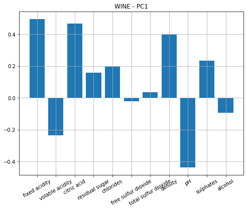

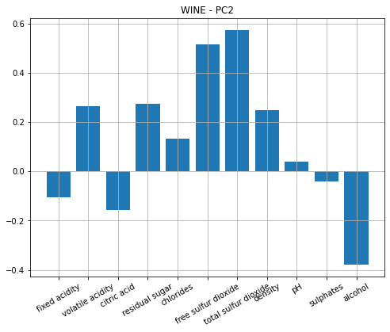

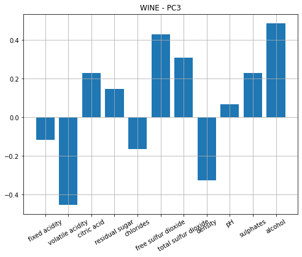

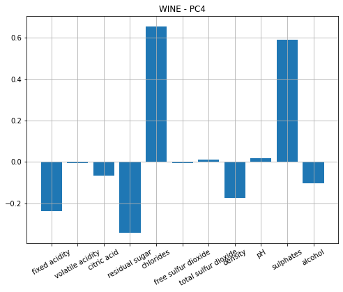

```python
plt.figure(figsize=(8, 6))
plt.bar(np.arange(pca_wine_m.n_features_), pca_wine_m.components_[0, :])
plt.xticks(ticks=np.arange(pca_wine_m.n_features_),
           labels=data.iloc[:,:-1].columns.to_list(),
           rotation=30)
plt.title('WINE - PC1')
plt.grid()
plt.show()

plt.figure(figsize=(8, 6))
plt.bar(np.arange(pca_wine_m.n_features_), pca_wine_m.components_[1, :])
plt.xticks(ticks=np.arange(pca_wine_m.n_features_),
           labels=pp_data.columns.to_list(),
           rotation=30)
plt.title('WINE - PC2')
plt.grid()
plt.show()

plt.figure(figsize=(8, 6))
plt.bar(np.arange(pca_wine_m.n_features_), pca_wine_m.components_[2, :])
plt.xticks(ticks=np.arange(pca_wine_m.n_features_),
           labels=pp_data.columns.to_list(),
           rotation=30)
plt.title('WINE - PC3')
plt.grid()
plt.show()

plt.figure(figsize=(8, 6))
plt.bar(np.arange(pca_wine_m.n_features_), pca_wine_m.components_[3, :])
plt.xticks(ticks=np.arange(pca_wine_m.n_features_),
           labels=pp_data.columns.to_list(),
           rotation=30)
plt.title('WINE - PC4')
plt.grid()
plt.show()
```

# Fisher Discriminant Analysis

#### Fisher Discriminant Analysis

**Sottospazio Multidimensionale** Nel caso in cui il sottospazio di Fisher è lo span di più direzioni di Fisher, $\{u_j\}_{i=1}^p$ dove $u_j \in \mathbb{R}^p$, il $d_B$ e $d_W$ sono definiti come: $$\mathbb{R} \ni d_B := tr(U^TS_BU),$$ $$\mathbb{R} \ni d_W := tr(U^TS_WU),$$ dove $\mathbb{R}^{d\times p}\ni U=[u_1,...,u_p]$. In questo caso, massimizzare il *criterio di Fisher* significa: $\underset{U}{mazimize}\;f(U):= \frac{d_B(U)}{d_W(U)}=\frac{tr(U^TS_BU)}{tr(U^TS_WU)}$. Il *criterio di Fisher* $f(U)$ è un *quoziente generalizzato di Rayleigh-Ritz*. Pertanto l'ottimizzazione dell'equazione di sopra è equivalente a: $$\underset{U}{mazimize}\;tr(U^TS_BU)$$ $$tale\;che\;U^TS_WU=I$$ Il *Lagrangiano* è: $$\mathcal{L}=tr(U^TS_BU)-tr(\Lambda^T(U^TS_WU-I))$$ dove $\Lambda\in\mathbb{R}^{d\times d}$ è una matrice diagonale le cui entrate diagonali sono i *moltiplicatori di Lagrange*. Eguagliando le derivate di $\mathcal{L}$ a zero si ottiene: $$\mathcal{R}^{d\times d}\ni\frac{\partial \mathcal{L}}{\partial U}=2S_WU\Lambda \overset{set}{=}0\implies 2S_BU=2S_WU\Lambda\implies S_BU=S_WU\Lambda,$$ che è un problema agli autovalori generalizzati $(S_B,S_W)$. Le colonne di $U$ sono gli autovettori ordinati dall'autovalore più grande al più piccolo (perchè in questo caso l'ottimizzazione è la massimizzazione) e le entrate diagonali di $\Lambda$ sono gli autovalori corrispondenti. Le colonne di $U$ vengono anche chiamate le *direzioni di Fisher* o gli *assi di Fisher*. Una possibile soluzione al problema agli autovalori generalizzati $(S_B,S_W)$ è: $$S_BU=S_wU\Lambda\implies S_W^{-1}S_BU=U\Lambda\implies U=eig((S_W+\epsilon I)^{-1}S_B),$$ Un altro modo per risolvere l'ottimizzazione sarebbe prendere le derivate dal *criterio di Fisher*: $$\mathbb{R}^{d\times p}\ni\frac{\partial f(U)}{\partial U}=\frac{1}{(tr(U^TS_WU))^2}\times [tr(U^TS_WU)(2S_BU)-tr(U^TS_BU)(2S_WU)]\overset{set}{=}0\overset{(a)}{\implies}S_BU=\frac{tr(U^TS_BU}{tr(U^TS_WU)}S_WU,$$ dove $(a)$ vale in quanto $tr(U^TS_WU)$ è uno scalare. L'equazione sopra è un problema agli autovalori generalizzati $(S_B,S_W)$ con colonne di $U$ come autovettori e $(u_j^TS_Bu_j)/(u_j^TS_Wu_j)$ come il j-esimo autovalore (in quanto l'ottimizzazione è la massimizzazione). Di nuovo, un altro modo di trovare le direzioni FDA è di considerare un'altra versione del criterio di Fisher. Il *criterio di Fisher* diventa $$f(U)=\frac{tr(U^T(S_T-S_W)U)}{tr(U^TS_WU)}=\frac{tr(U^TS_TU)}{tr(U^TS_WU)}-1.$$ Il $-1$ è una costante e viene persa nell'ottimizzazione, pertanto: $$\underset{U}{mazimize}\;tr(U^TS_BU)$$ $$tale\;che\;U^TS_WU=I$$ le cui soluzioni sono similmente ottenute come: $$S_TU=S_WU\Lambda,$$ che è un problema agli autovalori generalizzati $(S_T,S_W)$.

```python
X = pp_data.values
y = np.array(y_train)
```

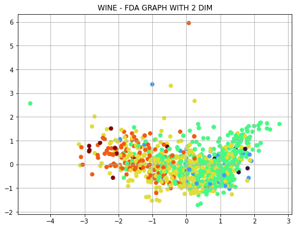

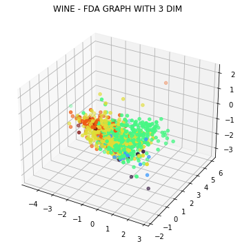

```python
fda_wine2 = FDA(n_dimensions=2)
fda_wine3 = FDA(n_dimensions=3)
fda_wine2.fit(X,y)
fda_wine3.fit(X,y)
Z2m = fda_wine2.transform(X)
Z3m = fda_wine3.transform(X)

plt.figure(figsize=(8, 6))
plt.scatter(Z2m[:, 0], Z2m[:, 1], c=y, cmap='turbo')
plt.title('WINE - FDA GRAPH WITH 2 DIM')
plt.grid()
plt.show()

fig_winescore = plt.figure(figsize=(8, 6))
ax = fig_winescore.add_subplot(111, projection='3d')
ax.scatter(Z3m[:, 0], Z3m[:, 1], Z3m[:, 2], c=y, cmap='turbo')
plt.title('WINE - FDA GRAPH WITH 3 DIM')
plt.grid()
plt.show()
```

## SVM sui dati della FDA

Si riapplichi la SVM ai dati trasformati dalla FDA

```python
X_test_array = X_test.values
y_test_array = np.array(y_test)
X_test_fda = fda_wine3.transform(X_test_array)
clf3 = SVC(C=30)
clf3.fit(Z3m, y)
y_pred = clf3.predict(X_test_fda)
f1_score(y_test_array, y_pred, average='macro')
```

```
0.09960159362549799
```

##### Essendo le classi poco separabili nella FDA in 3 dimensioni, la precisione dell'SVM è molto bassa, risultando in un f1 score del 10% circa (ma, avendo solo 3 dimensioni è più performante che nello spazio iniziale).

## Confronto plot FDA e PCA

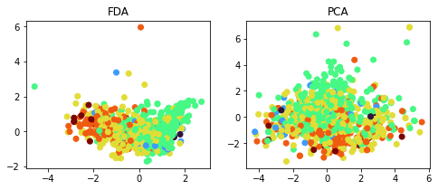

```python
# Plot a confronto

class_colors = [plt.cm.tab10.colors[c] for c in y[:num_tosee]]

# Plot per proiezione in R^2
fig2, axs2 = plt.subplots(1, 2, figsize=(8, 3))
axs2[0].scatter(Z2m[:num_tosee, 0], Z2m[:num_tosee, 1], c=y[:num_tosee],alpha=1, cmap='turbo')
axs2[0].set_title('FDA')
axs2[1].scatter(X_wine_m[:num_tosee,0], X_wine_m[:num_tosee,1],c=y[:num_tosee], alpha=1, cmap='turbo')
axs2[1].set_title('PCA')
```

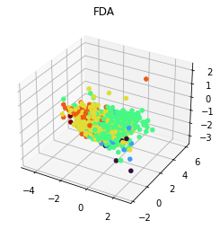

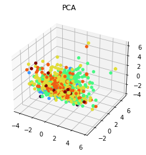

```python
# Plot a confronto

# Plot per proiezione in R^3
fig_Z3m = plt.figure(figsize=(5, 4))
ax_Z3m = fig_Z3m.add_subplot(111, projection='3d')
ax_Z3m.scatter(Z3m[:, 0], Z3m[:, 1], Z3m[:, 2], c=y, alpha=1, cmap='turbo')
plt.title('FDA')

fig_Z3p = plt.figure(figsize=(5, 4))
ax_Z3p = fig_Z3p.add_subplot(111, projection='3d')
ax_Z3p.scatter(X_wine_m[:, 0], X_wine_m[:, 1], X_wine_m[:, 2], c=y, alpha=1, cmap='turbo')
plt.title('PCA')
```

# KPCA

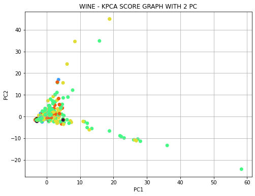

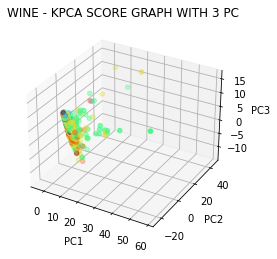

```python
random_seed = 20210528
kpca_wine = KPCA(kernel='poly', degree=2, coef0 = 4, gamma=0.4, random_state=random_seed, fit_inverse_transform=True)
#expld_variance_global = np.insert(np.cumsum(kpca_iris.explained_variance_ratio_), 0, 0)
Xkpca = kpca_wine.fit_transform(Xscaled)

plt.figure(figsize=(8, 6))
plt.scatter(Xkpca[:, 0], Xkpca[:, 1], c=y, cmap='turbo')
plt.title('WINE - KPCA SCORE GRAPH WITH 2 PC')
plt.xlabel('PC1')
plt.ylabel('PC2')
plt.grid()
plt.show()


fig_winescoreK = plt.figure()
ax = fig_winescoreK.add_subplot(111, projection='3d')
ax.scatter(Xkpca[:, 0], Xkpca[:, 1], Xkpca[:, 2], c=y, cmap='turbo')
plt.title('WINE - KPCA SCORE GRAPH WITH 3 PC')
ax.set_xlabel('PC1')
ax.set_ylabel('PC2')
ax.set_zlabel('PC3')
plt.grid()
plt.show()
```

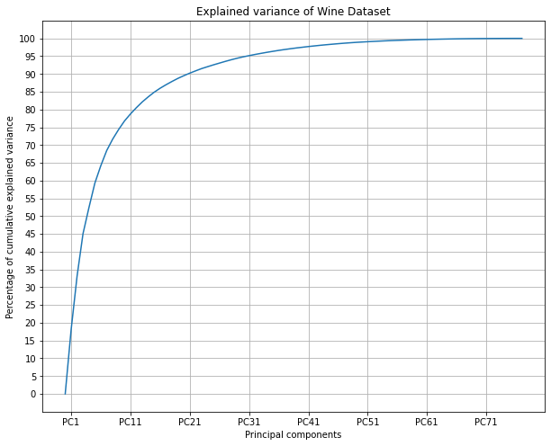

```python
plt.figure(figsize=(10,8))
#plt.plot(np.insert(100*np.cumsum(kpca_bean.lambdas_)/np.sum(kpca_bean.lambdas_), 0, 0))
plt.plot(np.insert(100*np.cumsum(kpca_wine.lambdas_)/np.sum(kpca_wine.lambdas_), 0, 0))
plt.title('Explained variance of Wine Dataset')
plt.xticks(ticks=np.arange(1, np.size(kpca_wine.lambdas_) + 1,10),
           labels=[f'PC{i}' for i in range(1, np.size(kpca_wine.lambdas_) + 1,10)])
plt.yticks(ticks=np.arange(0, 101, 5))
plt.xlabel('Principal components')
plt.ylabel('Percentage of cumulative explained variance')
plt.grid()
plt.show()
```

```python
def my_scorer(estimator, X, y=None):
    X_reduced = estimator.transform(X)
    X_preimage = estimator.inverse_transform(X_reduced)
    return -1 * mean_squared_error(X, X_preimage)

n_features = data.shape[1]
ker_list = ['poly','linear','rbf', 'cosine']
gamma_list = [1/(i*n_features) for i in np.arange(0.5, 1.5, 0.25)]
deg_list = [i for i in np.arange(1,4,1)]
coef_list = [2**i for i in range(-2,3)]

hparameters = {'kernel':ker_list, 'coef0':coef_list, 'gamma':gamma_list, 'degree':deg_list}
kpca = KPCA(n_components=3, fit_inverse_transform=True)

wine_kpca_GS = GridSearchCV(estimator=kpca,
                      param_grid=hparameters,
                      scoring=my_scorer,
                      return_train_score=True)
wine_kpca_GS.fit(Xscaled)
df_results = pd.DataFrame(wine_kpca_GS.cv_results_)
#indices = [0, 1, 2, 3, 4, 5, 6, 7, 8, 16]
#df = df_results.iloc[:, indices]
display(df_results.sort_values(['rank_test_score'], ascending=True))
```

|  | mean_fit_time | std_fit_time | mean_score_time | std_score_time | param_coef0 | param_degree | param_gamma | param_kernel | params | split0_test_score | ... | mean_test_score | std_test_score | rank_test_score | split0_train_score | split1_train_score | split2_train_score | split3_train_score | split4_train_score | mean_train_score | std_train_score |
| --- | --- | --- | --- | --- | --- | --- | --- | --- | --- | --- | --- | --- | --- | --- | --- | --- | --- | --- | --- | --- | --- |
| 220 | 0.042161 | 0.001248 | 0.004170 | 0.000451 | 4 | 2 | 0.066667 | poly | {'coef0': 4, 'degree': 2, 'gamma': 0.066666666... | -0.680863 | ... | -0.732086 | 0.046975 | 1 | -2.883595e-26 | -3.535144e-26 | -3.393904e-26 | -3.749741e-26 | -3.412661e-26 | -3.395009e-26 | 2.854224e-27 |
| 216 | 0.058458 | 0.009095 | 0.004235 | 0.000659 | 4 | 2 | 0.083333 | poly | {'coef0': 4, 'degree': 2, 'gamma': 0.083333333... | -0.647289 | ... | -0.732607 | 0.072567 | 2 | -2.997260e-26 | -3.864657e-26 | -3.462136e-26 | -3.737065e-26 | -3.202110e-26 | -3.452646e-26 | 3.227638e-27 |
| 212 | 0.045655 | 0.001051 | 0.003999 | 0.000481 | 4 | 2 | 0.111111 | poly | {'coef0': 4, 'degree': 2, 'gamma': 0.111111111... | -0.738009 | ... | -0.764889 | 0.076214 | 3 | -4.442856e-26 | -6.372438e-26 | -3.517701e-26 | -5.112035e-26 | -3.689399e-26 | -4.626886e-26 | 1.041668e-26 |
| 172 | 0.057061 | 0.005698 | 0.005568 | 0.001500 | 2 | 2 | 0.066667 | poly | {'coef0': 2, 'degree': 2, 'gamma': 0.066666666... | -0.819473 | ... | -0.806726 | 0.055629 | 4 | -2.220548e-27 | -2.327679e-27 | -2.091061e-27 | -2.227371e-27 | -2.131808e-27 | -2.199693e-27 | 8.245076e-29 |
| 225 | 0.041341 | 0.003278 | 0.004172 | 0.000409 | 4 | 3 | 0.166667 | linear | {'coef0': 4, 'degree': 3, 'gamma': 0.166666666... | -0.774775 | ... | -0.828968 | 0.051075 | 5 | -3.949529e-27 | -4.627227e-27 | -4.063906e-27 | -3.558926e-27 | -3.476715e-27 | -3.935260e-27 | 4.116947e-28 |
| ... | ... | ... | ... | ... | ... | ... | ... | ... | ... | ... | ... | ... | ... | ... | ... | ... | ... | ... | ... | ... | ... |
| 132 | 0.091444 | 0.002185 | 0.014914 | 0.000081 | 1 | 3 | 0.111111 | poly | {'coef0': 1, 'degree': 3, 'gamma': 0.111111111... | -44.190187 | ... | -42.391540 | 62.441752 | 236 | -1.611802e-20 | -9.106332e-20 | -3.143722e-21 | -7.453885e-20 | -1.936134e-19 | -7.569547e-20 | 6.775749e-20 |
| 176 | 0.090497 | 0.002607 | 0.015750 | 0.001170 | 2 | 3 | 0.166667 | poly | {'coef0': 2, 'degree': 3, 'gamma': 0.166666666... | -438.763801 | ... | -132.082254 | 174.692673 | 237 | -1.179858e-15 | -5.623283e-15 | -2.709114e-16 | -7.907566e-16 | -5.858643e-16 | -1.690135e-15 | 1.988594e-15 |
| 32 | 0.087129 | 0.002673 | 0.015375 | 0.000364 | 0.25 | 3 | 0.166667 | poly | {'coef0': 0.25, 'degree': 3, 'gamma': 0.166666... | -409.007979 | ... | -135.353787 | 169.361043 | 238 | -2.975590e-17 | -6.935194e-16 | -9.132175e-18 | -1.796224e-16 | -3.288336e-17 | -1.889826e-16 | 2.595039e-16 |
| 80 | 0.087252 | 0.003357 | 0.015308 | 0.000351 | 0.5 | 3 | 0.166667 | poly | {'coef0': 0.5, 'degree': 3, 'gamma': 0.1666666... | -1322.376678 | ... | -339.882431 | 510.960516 | 239 | -2.706510e-16 | -7.642424e-16 | -1.017471e-16 | -2.064734e-16 | -2.571148e-16 | -3.200457e-16 | 2.298973e-16 |
| 128 | 0.093348 | 0.002257 | 0.015565 | 0.000805 | 1 | 3 | 0.166667 | poly | {'coef0': 1, 'degree': 3, 'gamma': 0.166666666... | -2621.413629 | ... | -585.878752 | 1024.038717 | 240 | -1.159463e-15 | -1.036629e-15 | -5.875767e-17 | -1.437329e-15 | -1.478946e-15 | -1.034225e-15 | 5.152662e-16 |

240 rows × 24 columns

##### Si plottino ora i punti nelle prime 3 componenti principali della KPCA con il miglior stimatore.

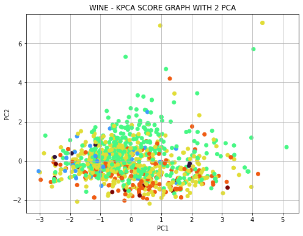

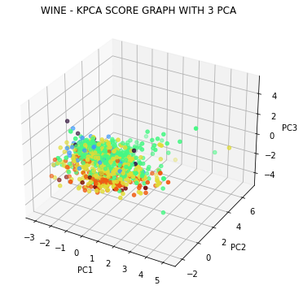

```python
wine_kpca_GS.best_estimator_.fit(Xscaled)
X_wine_K = wine_kpca_GS.transform(Xscaled)

plt.figure(figsize=(8, 6))
plt.scatter(X_wine_K[:, 0], X_wine_K[:, 1], c=y, cmap='turbo')
plt.title('WINE - KPCA SCORE GRAPH WITH 2 PCA')
plt.xlabel('PC1')
plt.ylabel('PC2')
plt.grid()
plt.show()

fig_winescore = plt.figure(figsize=(8, 6))
ax = fig_winescore.add_subplot(111, projection='3d')
ax.scatter(X_wine_K[:, 0], X_wine_K[:, 1], X_wine_K[:, 2], c=y, cmap='turbo')
plt.title('WINE - KPCA SCORE GRAPH WITH 3 PCA')
ax.set_xlabel('PC1')
ax.set_ylabel('PC2')
ax.set_zlabel('PC3')
plt.grid()
plt.show()
```

# KFDA

```python
import kfda
from kfda import Kfda as KFDA
kfda_2dim = KFDA(n_components=2, kernel='linear')
kfda_2dim.fit(X,y)
Z2k = kfda_2dim.transform(X);
```

##### Si plottino ora i punti in due dimensioni proiettati con la FDA e la KFDA con kernel lineare

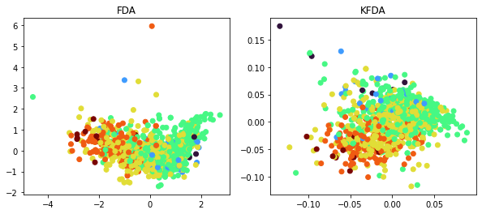

```python
# Plot per proiezione in R^2
fig2, axs2 = plt.subplots(1, 2, figsize=(10, 4))
axs2[0].scatter(Z2m[:, 0], Z2m[:, 1], c=y, alpha=1,cmap= 'turbo')
axs2[0].set_title('FDA')
axs2[1].scatter(Z2k[:, 0], Z2k[:, 1], c=y, alpha=1,cmap= 'turbo')
axs2[1].set_title('KFDA')
```

##### Si faccia ora, come fatto in precedenza con i parametri della KPCA, una gridsearch per trovare il miglior stimatore per la KFDA.

```python
n_features = data.shape[1]
#ker_list = ['rbf', 'linear', 'poly', 'sigmoid', 'cosine']
ker_list = ['rbf', 'linear', 'cosine','poly']
gamma_list = [1/(i*n_features) for i in np.arange(0.5, 1.5, 0.25)]
deg_list = [i for i in np.arange(1,5,1)]
coef_list = [2**i for i in range(-2,3)]

hparameters = {'kernel':ker_list}
kfda3 = KFDA(n_components=3, robustness_offset=3e-8)

kfda_wine_GS3 = GridSearchCV(estimator=kfda3,
                      param_grid=hparameters,
                      scoring='f1_weighted',
                      return_train_score=True);
kfda_wine_GS3.fit(X,y);
df_results = pd.DataFrame(kfda_wine_GS3.cv_results_);
#indices = [0, 1, 2, 3, 4, 5, 6, 7, 8, 16]
#df = df_results.iloc[:, indices]
display(df_results.sort_values(['rank_test_score'], ascending=True));
```

|  | mean_fit_time | std_fit_time | mean_score_time | std_score_time | param_kernel | params | split0_test_score | split1_test_score | split2_test_score | split3_test_score | ... | mean_test_score | std_test_score | rank_test_score | split0_train_score | split1_train_score | split2_train_score | split3_train_score | split4_train_score | mean_train_score | std_train_score |
| --- | --- | --- | --- | --- | --- | --- | --- | --- | --- | --- | --- | --- | --- | --- | --- | --- | --- | --- | --- | --- | --- |
| 0 | 0.112925 | 0.001927 | 0.004704 | 0.000383 | rbf | {'kernel': 'rbf'} | 0.375828 | 0.446544 | 0.481415 | 0.505171 | ... | 0.463808 | 0.049397 | 1 | 0.971963 | 0.981328 | 0.983665 | 0.995335 | 0.988336 | 0.984125 | 0.007738 |
| 1 | 0.098344 | 0.002623 | 0.002429 | 0.000498 | linear | {'kernel': 'linear'} | 0.485947 | 0.454763 | 0.472353 | 0.378895 | ... | 0.459221 | 0.043306 | 2 | 0.445485 | 0.479811 | 0.494067 | 0.492551 | 0.473915 | 0.477166 | 0.017570 |
| 2 | 0.098911 | 0.001282 | 0.002413 | 0.000496 | cosine | {'kernel': 'cosine'} | 0.442820 | 0.431815 | 0.462236 | 0.341268 | ... | 0.432248 | 0.048734 | 3 | 0.429174 | 0.435200 | 0.428878 | 0.467513 | 0.437554 | 0.439664 | 0.014327 |
| 3 | 0.125911 | 0.002994 | 0.009383 | 0.000465 | poly | {'kernel': 'poly'} | 0.376616 | 0.351600 | 0.348038 | 0.389243 | ... | 0.376041 | 0.024704 | 4 | 0.584126 | 0.540346 | 0.614427 | 0.564857 | 0.547331 | 0.570217 | 0.026806 |

4 rows × 21 columns

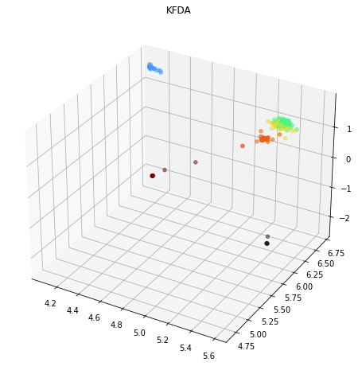

```python
kfda_wine_GS3.best_estimator_.fit(X, y)
X_wine_Kfda3 = kfda_wine_GS3.transform(X)

fig_Z3K = plt.figure(figsize=(10, 8))
ax_Z3K = fig_Z3K.add_subplot(111, projection='3d')
ax_Z3K.scatter(X_wine_Kfda3[:, 0], X_wine_Kfda3[:, 1], X_wine_Kfda3[:, 2], c=y, alpha=0.5, cmap='turbo')
plt.title('KFDA')
```

```python
from sklearn.metrics import classification_report
X_test_array = X_test.values
y_test_array = np.array(y_test)
X_test_kfda = kfda_wine_GS3.transform(X_test_array)
clf3 = SVC(C=0.2)
clf3.fit(X_wine_Kfda3, y)
y_pred = clf3.predict(X_test_kfda)
f1_score(y_test, y_pred, average='micro')
```

```
0.032196969696969696
```

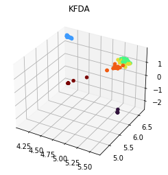

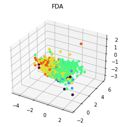

```python
fig_Z3K = plt.figure(figsize=(5, 4))
ax_Z3K = fig_Z3K.add_subplot(111, projection='3d')
ax_Z3K.scatter(X_wine_Kfda3[:, 0], X_wine_Kfda3[:, 1], X_wine_Kfda3[:, 2], c=y, alpha=1, cmap='turbo')
plt.title('KFDA')

fig_Z3m = plt.figure(figsize=(5, 4))
ax_Z3m = fig_Z3m.add_subplot(111, projection='3d')
ax_Z3m.scatter(Z3m[:, 0], Z3m[:, 1], Z3m[:, 2], c=y, alpha=1, cmap='turbo')
plt.title('FDA')
```

# Appendice sugli RKHS

## 1. REPRODUCING KERNEL HILBERT SPACES

### 1.1 *Definizione di funzionale di valutazione di Dirac*

Sia $ \mathbb{H} $ lo spazio $ \mathbb{L}_2 (X) $ di funzioni da $X$ in $\mathbb{R}$ per qualche insieme non vuoto $X$. Si definisce il **funzionale di valutazione di Dirac in $x$** il funzionale $\delta_x$ tale che $$ \delta_x : \mathbb{H} \to \mathbb{R}\quad \text{tale che}\quad\delta_x (f) = f(x) $$ $\delta_x$ è continuo se esiste una costante $M>0$, $M \in \mathbb{R}$ tale che $$ \lvert\lvert{\delta_x (f)\rvert\rvert}_{\mathbb{L}_2} = \lvert{f(x)\rvert} \leq M \lvert\lvert{f\rvert\rvert}_{\mathbb{L}_2} \quad \forall f \in \mathbb{H}, \quad \forall x \in \mathbb{R}^n $$

### 1.2 *Definizione di RKHS*

Un **RKHS** (Reproducing Kernel Hilbert Space) è uno spazio di Hilbert in cui ogni funzionale di valutazione di Dirac è continuo.

### 1.3 *Teorema di rappresentazione di Riesz*

Sia $\mathbb{H}$ uno spazio di Hilbert. Allora per ogni funzionale lineare e continuo $\Phi$ su $\mathbb{H}$, esiste ed è unico un elemento $u$ di $\mathbb{H}$ tale che $$ \Phi (f) = \langle f, u \rangle_{\mathbb{H}} $$

Nel caso dei funzionali di valutazione di Dirac, se siamo in un RKHS allora per ogni $\delta_x$ esiste ed è unico $k_x \in \mathbb{H}$ tale che $$ \delta_x (f) = f(x) = \langle f, k_x \rangle_{\mathbb{H}} $$ $k_x$ viene detto **representer in $x$**.

### 1.4 *Definizione di Reproducing Kernel*

Sia $\mathbb{H}$ uno spazio di Hilbert di funzioni da $X$ in $\mathbb{R}$ con $X$ insieme non vuoto. Una funzione $\mathcal{K} : X \times X \to \mathbb{R}$ si dice **Reproducing Kernel** di $\mathbb{H}$ se soddisfa:

- $\forall x \in X \quad k_x = \mathcal{K}(\cdot,x) \in \mathbb{H}$, $k_x$ si dice **representer in $x$**
- $\mathcal{K}(x,x) < \infty \quad \forall x \in X$
- $\forall x \in X, \forall f \in \mathbb{H} \quad \langle f, \mathcal{K}(\cdot,x) \rangle = f(x)$ (**Reproducing Property**)

Osserviamo che $k_x \in \mathbb{H}$ è una funzione da $X$ in $\mathbb{R}$ tale che $k_x (y) = \mathcal{K}(x,y)$ In particolare, per ogni $x,y \in X$ $$ \langle k_x, k_y \rangle_{\mathbb{H}} = \langle \mathcal{K}(\cdot,x), \mathcal{K}(\cdot,y) \rangle_{\mathbb{H}} = \mathcal{K}(x,y) = \mathcal{K}(y,x) $$ dove $k_x, k_y$ sono rispettivamente i representer di $\delta_x, \delta_y$. Segue chiaramente che $\mathcal{K}$ è simmetrico e definito positivo, perche discende dal prodotto scalare su $\mathbb{H}$.

Chiaramente se $k_x \in \mathbb{H} \;\; \forall x \in X$, allora $\textbf{span}\{ k_x : x \in X \} \subseteq \mathbb{H}$, quindi se $f = \sum_{j=1}^N \alpha_j \mathcal{K}(\cdot,x_j)$ con $x_j \in X$, allora $$ \vert\vert f \vert\vert_{\mathbb{H}}^2 = \sum_{j=1}^N \sum_{i=1}^N \alpha_j \alpha_i \langle \mathcal{K}(\cdot, x_j),\mathcal{K}(\cdot, x_i) \rangle_{\mathbb{H}} = \sum_{j=1}^N\sum_{i=1}^N \alpha_j \alpha_i \mathcal{K}(x_j, x_i) $$

### 1.5 *Teorema di unicità*

Se esiste, il reproducing kernel $\mathcal{K}$ per uno spazio di Hilbert $\mathbb{H}$ è unico.

##### *Dimostrazione*

Assumiamo che $\mathbb{H}$ abbia due Reproducing Kernel $\mathcal{K}_1$ e $\mathcal{K}_2$. Allora $$ \langle f, \mathcal{K}_1 (\cdot, x) - \mathcal{K}_2 (\cdot, x) \rangle = f(x) - f(x) = 0 \quad \forall f \in \mathbb{H},\; \forall x \in X $$ In particolare, se prendiamo $f = \mathcal{K}_1 (\cdot, x) - \mathcal{K}_2 (\cdot, x)$ otteniamo $$ \vert\vert \mathcal{K}_1 (\cdot, x) - \mathcal{K}_2 (\cdot, x) \vert\vert_{\mathbb{H}}^2 = 0 \;\; \forall x \in X \implies \mathcal{K}_1 = \mathcal{K}_2 $$

### 1.6 _Equivalenza tra Reproducing Kernel e $\delta_x$ limitato_

Sia $\mathbb{H}$ uno spazio di Hilbert di funzioni $f : X \to\mathbb{R}$. Allora gli operatori di valutazione $\delta_x$ sono funzionali limitati e continui $\iff$ $\mathbb{H}$ ha un Reproducing Kernel $\mathcal{K}$

##### *dimostrazione*

$( \Longleftarrow )$ Poiché $\mathbb{H}$ è uno spazio di Hilbert con Reproducing Kernel $\mathcal{K}$, allora $$ | \delta_x f | = | f(x) | = | \langle f, \mathcal{K} (\cdot, x) \rangle_{\mathbb{H}} | \leq || \mathcal{K}(\cdot, x ) ||_{\mathbb{H}} || f ||_{\mathbb{H}} = \langle \mathcal{K}(\cdot, x), \mathcal{K}(\cdot, x) \rangle_{\mathbb{H}}^{\frac{1}{2}} || f ||_{\mathbb{H}} = \mathcal{K}(x,x)^{\frac{1}{2}} || f ||_{\mathbb{H}} $$ $ \implies $ $\delta_x : \mathbb{H} \to \mathbb{R}$ è un operatore lineare e limitato.

$ ( \Longrightarrow ) $ Supponiamo che $\delta_x : \mathbb{H} \to \mathbb{R}$ sia un funzionale lineare e limitato. Allora per il teorema di rappresentazione di Riesz $\implies$ $\exists f_{\delta_x} \in \mathbb{H}$ tale che $\delta_x f = \langle f, f_{\delta_x} \rangle_{\mathbb{H}}\;\; \forall f \in \mathbb{H} $. Definiamo $\mathcal{K} (x', x) = f_{\delta_x} (x') \quad \forall x, x' \in X$. Allora $$ \mathcal{K} (\cdot, x) = f_{\delta_x} \;\; \text{e}\;\; \langle f, \mathcal{K} (\cdot, x) \rangle_{\mathbb{H}} = \delta_x f = f(x) $$ $\implies$ $\mathcal{K}$ è un Reproducing Kernel per $\mathbb{H}$

### 1.7 *Definizione di Kernel*

Una funzione $\mathcal{K} : X \times X \to \mathbb{R} $ si dice **Kernel** su un insieme non vuoto $X$ se esiste uno spazio di Hilbert $\mathbb{H}$ (non necessariamente RKHS) e una mappa $\Phi : X \to \mathbb{H}$, tale che $$ \mathcal{K}(x,y) = \langle \Phi(x), \Phi(y) \rangle_{\mathbb{H}} $$ $\Phi$ è chiamata **Feature Map**, e $\mathbb{H}$ è chiamato **Feature Space**

Si dimostra che ogni Reproducing Kernel è anche un Kernel. Basta prendere come $\Phi$ la funzione che manda $ x \mapsto \mathcal{K}(\cdot,x) = k_x$, con $k_x \in \mathbb{H}$ e quindi $\mathcal{K}(x,y) = \langle \mathcal{K},\mathcal{K}(\cdot, y) \rangle_{\mathbb{H}}$. Allora il RKHS $\mathbb{H}$ è il Feature Space. **N.B.** Non vale il viceversa, in quanto verrebbe meno l'unicità.

Un Kernel $\mathcal{K}$ può essere visto come una matrice di infinite dimensioni, ma nonostante questo esistono due diverse definizioni di Kernel definito positivo, equivalenti nel caso di Kernel continui.

#### 1.7.1 *Kernel definito positivo*

Un Kernel simmetrico $\mathcal{K} : X \times X \to \mathbb{R}$ si dice **(semi-)definito positivo** su $X$ se la sua matrice di kernel associata $(\mathcal{K})_{i,j} = \mathcal{K}(x_i, x_j)_{i,j=1}^N$ è (semi-)definita positiva $\forall N \in \mathbb{N}$ e per ogni insieme di punti distinti $\{ x_1, \ldots, x_N \} \subset X$.

#### 1.7.2 *Kernel integralmente definito positivo*

Un Kernel simmetrico $\mathcal{K} : X \times X \to \mathbb{R}$ si dice **semi-definito positivo in $\mathbb{L}_2$** se per ogni funzione $f \in \mathbb{L}_2$ si ha che $$ \int_X \int_X f(x) \mathcal{K}(x,x') f(x') dx dx' \geq 0 $$ ed si dice **definito positivo in $\mathbb{L}_2$** se l'integrale è uguale a $0$ $\iff$ $f \equiv 0$ quasi ovunque.

#### 1.8 *Teorema*

Ogni Kernel è una funzione semi-definita positiva.

##### *Dimostrazione*

Siano $\{ x_1, \ldots, x_N \} \subset X$ distinti e $c \in \mathbb{R}^N$. Abbiamo che $$ \sum_{i=1}^N \sum_{j=1}^N c_i c_j \mathcal{K} (x_i, x_j) =\sum_{i=1}^N \sum_{j=1}^N c_i c_j \langle \phi (x_i), \phi (x_j) \rangle_{\mathbb{H}} =\bigg\langle \sum_{i=1}^N c_i \phi (x_i), \sum_{j=1}^N c_j \phi (x_j) \bigg\rangle_{\mathbb{H}} = \bigg|\bigg| \sum_{i=1}^N c_i \phi (x_i) \bigg|\bigg|_{\mathbb{H}}^2 \geq 0$$ Reproducing Kernel $\implies$ Kernel $\implies$ funzione semi-definita positiva

Un primo modo per costruire un RKHS a partire da un Kernel e dato dal seguente risultato

### 1.9 *Teorema di Moore-Aronszajn*

Sia $\mathcal{K} : X \times X \to \mathbb{R}$ un kernel definito positivo. Allora esiste ed è unico (a meno di isomorfismi) un RKHS $\mathbb{H}_{\mathcal{K}} \in \mathbb{R}^X$ con Reproducing Kernel $\mathcal{K}$.

##### *Dimostrazione Teorema*

Per ipotesi $\mathcal{K}$ è un Kernel definito positivo. Definiamo $\mathbb{H}_0 = \textbf{span} \{ k_x : x \in X \}$, per cui ogni elemento di $\mathbb{H}_0$ può essere scritto come $\sum_i \alpha_i k_{x_i} = \sum_i \alpha_i \mathcal{K}(\cdot, x_i) $, e ci definiamo una forma bilineare $$ \langle f_1, f_2 \rangle_{\mathcal{K}} = \bigg\langle \sum_{i=1}^N \alpha_i \mathcal{K}(\cdot, x_i), \sum_{j=1}^N \beta_j \mathcal{K}(\cdot, y_j) \bigg\rangle_{\mathcal{K}} =\sum_{i=1}^N \sum_{j=1}^N \alpha_i \beta_j \mathcal{K} (x_i, y_j) $$

##### 1.9.1 *Lemma*

Se $\mathcal{K} : X \times X \to \mathbb{R}$ è un Kernel simmetrico definito positivo $\implies$ $\langle \cdot, \cdot \rangle_{\mathcal{K}}$ definisce un prodotto interno su $\mathbb{H}_0$. Inoltre $\mathbb{H}_0$ è uno spazio pre-hilbertiano con Reproducing Kernel $\mathcal{K}$.

##### *Dimostrazione Lemma*

Ovviamente $\langle \cdot, \cdot \rangle_{\mathcal{K}}$ è bilineare e simmetrico. Inoltre, se consideriamo una qualsiasi funzione $f = \sum_{j=1}^N \alpha_j \mathcal{K}(\cdot, x_j) \not= 0$ in $\mathbb{H}_0$, troviamo che $$ \langle f, f \rangle_{\mathcal{K}} = \sum_{j = 1}^N \sum_{k = 1}^N \alpha_j \alpha_k \mathcal{K} (x_j, x_k) > 0 $$ perché per ipotesi $\mathcal{K}$ è definito positivo. Infine otteniamo che $$ \langle f, \mathcal{K}(\cdot, y) \rangle_{\mathcal{K}} = \sum_{j=1}^N \alpha_j \mathcal{K} (x_j, y) = f(y) $$ $\implies$ $\mathbb{H}_0$ è uno spazio pre-hilbertiano con Reproducing Kernel $\mathcal{K}$.

Notiamo però che $\mathbb{H}_0$ non è necessariamente completo, per cui cerchiamo di farne il completamento. Definiamo quindi $\mathbb{H}_{\mathcal{K}}$ come lo spazio di funzioni $f \in \mathbb{R}^X$ per esiste una sequenza $\{ f_n \}$ di Cauchy in $\mathbb{H}_0$. Fissiamo $x \in X$ e consideriamo $$ | f_n (x) - f_m (x) | = | \langle \mathcal{K}(x,\cdot), f_n - f_m \rangle | \leq || \mathcal{K} (x,\cdot) ||_{\mathbb{H}_0} || f_n - f_m ||_{\mathbb{H}_0} = \langle \mathcal{K}(x,\cdot), \mathcal{K}(x,\cdot) \rangle^{\frac{1}{2}}_{\mathbb{H}_0} || f_n - f_m ||_{\mathbb{H}_0} = \mathcal{K}(x,x)^{\frac{1}{2}} || f_n - f_m ||_{\mathbb{H}_0} $$ Per definizione sappiamo che $\mathcal{K}(x,x) < \infty \;\; \forall x \in X$, da cui segue che $\{ f_n (x) \}$ è una successione limitata di Cauchy in $\mathbb{R}$, che è completo $\implies$ esiste $f(x) = \lim f_n (x)$. Allora aggiungiamo a $\mathbb{H}_0$ tutte le funzioni così definite per ottenere $\mathbb{H}_{\mathcal{K}}$, per cui infine $\forall x \in X$ abbiamo che $$ f(x) = \lim_{n \to \infty} f_n (x) = \lim_{n \to \infty} \langle f_n, \mathcal{K}(\cdot,x) \rangle_{\mathbb{H}_0} = \langle f, \mathcal{K}(\cdot,x) \rangle_{\mathbb{H}_{\mathcal{K}}} $$ per cui $\mathcal{K}$ e' il Reproducing Kernel di $\mathbb{H}_{\mathcal{K}}$.

Un'altra costruzione di RKHS a partire da un Kernel viene data in termini di autofunzioni associate all'operatore con nucleo integrale definito da $$ T_{\mathcal{K}}(q)(x) = \int_X \mathcal{K}(x,y) q(y) dy \quad q \in \mathbb{L}_2 (X), \; x \in X $$ Affinche questo operatore sia ben definito, e necessario che la norma in $\mathbb{L}_2 (X)$ sia finita $$ \int \int \mathcal{K}^2 (x,x') dx dx' < \infty \implies \mathcal{K}(\cdot,x) \in \mathbb{L}_2 (X) $$ Questa proprieta si dice **traccia finita**.

### 1.10 *Teorema di Mercer*

Sia $\mathcal{K}$ un Kernel definito positivo, continuo e con traccia finita. Sia $T_{\mathcal{K}}$ l'operatore con nucleo integrale definito sopra, che sappiamo essere ben definito. Allora esiste una sequenza infinita di autofunzioni $\{ \phi_i \}_{i =0}^{\infty} $ e di autovalori $\{ \lambda_i \}_{i=0}^{\infty}$ di $T_{\mathcal{K}}$, con $\lambda_1 \geq \lambda_2 \geq \ldots$ tale che $\mathcal{K}$ puo essere scritto come $$ \mathcal{K} (x,x') = \sum_{i = 0}^{\infty} \lambda_i \phi_i (x) \phi_i (x') $$

Questo risultato permette di costruire un RKHS $\mathbb{H}_{\mathcal{K}}$ in questo modo: $$ \mathbb{H}_{\mathcal{K}} := \bigg\{ f : f = \sum_{i = 0}^{\infty} c_i \phi_i \bigg\} $$ Chiaramente $f \in \mathbb{L}_2$, per cui i coefficienti saranno dati da $$ f_i = \langle f, \phi_i \rangle_{\mathbb{L}_2} = \int f(x) \phi_i (x) dx $$ E' un risultato base dell'analisi di Fourier che tale rappresentazione esiste ed e' unica.

Dato cio', possiamo ora definire il prodotto interno su $\mathbb {H}_{\mathcal{K}}$: $$\langle f,g \rangle_{\mathbb{H}_{\mathcal{K}}} = \sum_{i=0}^{\infty} \frac{f_i g_i}{\lambda_i}$$ dove abbiamo usato la $\mathbb{H}_{\mathcal{K}}$-ortogonalita' $\langle \phi_j, \phi_k \rangle_{\mathbb{H}_{\mathcal{K}}} = \cfrac{\delta_{j,k}}{\sqrt{\lambda_j}\sqrt{\lambda_k}}$ delle autofunzioni.

**Nota:** $\mathcal{K}$ e' il reproducing kernel di $\mathbb{H}_{\mathcal{K}}$ dato che l'espansione in autofunzioni di $\mathcal{K}$, data dal *Teorema di Mercer*, e l'ortogonalita' delle autofunzioni implicano che $$\langle f,\mathcal{K}(\cdot,x)\rangle_{\mathbb{H}_{\mathcal{K}}} = \bigg\langle\sum_{j=0}^\infty c_j\phi_j, \sum_{j=0}^\infty \lambda_i \phi_i \phi_i(x)\bigg\rangle_{\mathbb{H}_{\mathcal{K}}} = \sum_{i=0}^\infty \cfrac{c_i\lambda_i\phi_i(x)}{\lambda_i} = \sum_{i=0}^\infty c_i\phi_i(x) = f(x)$$

### 1.11 *Kernel trick*

Dato un kernel $\mathcal{K}$ esiste una feature map associata $\Phi : X\to\mathbb{H}$ tale che $$\mathcal{K}(x,x') = \langle \Phi(x),\Phi(x')\rangle_{\mathbb{H}}$$ per esempio dato un kernel $\mathcal{K}$ esiste una funzione $\Phi$ tale che la valutazione del kernel nei punti $x$ e $x'$ e' equivalente a prendere il profotto scalare tra $\Phi(x)$ $\Phi(x')$ in alcuni (forse sconosciuti) spazi di Hilbert.

Questo ci da' la possibilita' di utilizzare il *kernel trick*, nel quale trasformiamo gli input in $\mathbb{H}$ usando $\Phi$ e quindi prendiamo il prodotto scalare come prima.

Abbiamo visto come costruire un *RKHS* $\mathbb{H}$ partendo da un kernel definito positivo e che $\mathbb{H}_{\mathcal{K}}$ e' unico a meno di isomorfismi.

Questo significa che $\Phi$ non e' unico in modo assoluto, ma lo e' preso $\mathbb{H}$.